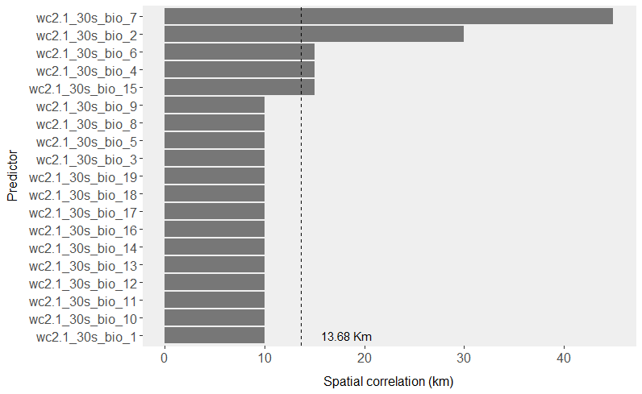

Spatial corr.

GBIF Strix aluco presence only verisi sampling bias ve

spatial auto-correlation düzeltmesi için *inceltildi*.

Input Records: 1473

Final Records: 271

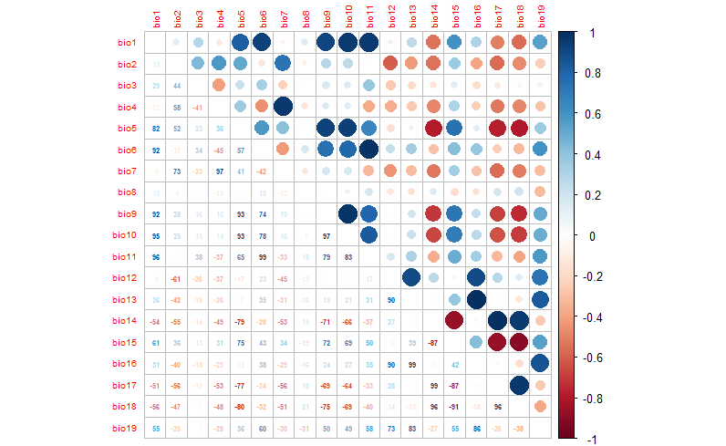

Correlation Matrix

**Akaike information criterion** göre değişken önemleri (WorldClim2.1 Bioclimatic variables)

variable AIC

1 bio7 1569.065

2 bio4 1569.907

3 bio6 1660.357

4 bio2 1685.776

5 bio19 1693.831

6 bio13 1694.068

7 bio16 1697.914

8 bio12 1698.536

9 bio11 1701.122

10 bio1 1787.342

11 bio10 1795.081

12 bio15 1819.637

13 bio5 1821.390

14 bio17 1824.509

15 bio14 1827.964

16 bio9 1833.760

17 bio3 1841.781

18 bio18 1844.596

19 bio8 1851.372

**|r|<0.7** ve **AIC** ye göre seçilen az “correlated” değişkenler: **“bio7” “bio6” “bio19” “bio15” “bio3” “bio8”**

Veri %80 training, %20 test şeklinde ayrılarak 5 model fitlendi: **generalized linear model, generalized additive model, random forest, boosted regression trees ve maxent**.

```r
library(knitr)
comp_perf <- readRDS(file = "comp_perf.rds")
kable(x = comp_perf)
```

|  | AUC | TSS | Kappa | Sens | Spec | PCC | D2 | thresh | alg |
| --- | --- | --- | --- | --- | --- | --- | --- | --- | --- |
| glm | 0.8290068 | 0.5317808 | 0.2066983 | 0.84 | 0.6917808 | 0.7034700 | 0.1978010 | 0.08 | glm |
| gam | 0.8307534 | 0.5249315 | 0.2011760 | 0.84 | 0.6849315 | 0.6971609 | 0.2010325 | 0.08 | gam |
| rf | 0.8468836 | 0.5644521 | 0.1824380 | 0.96 | 0.6044521 | 0.6324921 | 0.2137700 | 0.05 | rf |
| brt | 0.8276712 | 0.4813699 | 0.2514490 | 0.68 | 0.8013699 | 0.7917981 | 0.1983672 | 0.11 | brt |
| maxent | 0.8357877 | 0.5386301 | 0.2123798 | 0.84 | 0.6986301 | 0.7097792 | -0.3340441 | 0.35 | maxent |

Ensemble ortalamaları: (ağırlıklı ortalama true skill statistic’e göre)(committee_av: olasılık tahminlerinin **maxSens+Spec threshold**’a göre var/yok tahminlerine dönüştürülüp tekrar ortalamanın alınması)

```r
library(knitr)
ens_perf <- readRDS(file = "ens_perf.rds")
kable(x = ens_perf)
```

|  | AUC | TSS | Kappa | Sens | Spec | PCC | D2 | thresh |
| --- | --- | --- | --- | --- | --- | --- | --- | --- |
| mean_prob | 0.8391781 | 0.5301370 | 0.1809743 | 0.90 | 0.6301370 | 0.6514196 | 0.1655039 | 0.100 |
| median_prob | 0.8350342 | 0.5232192 | 0.1998195 | 0.84 | 0.6832192 | 0.6955836 | 0.2062290 | 0.080 |
| wmean_prob | 0.8394863 | 0.5403425 | 0.2138259 | 0.84 | 0.7003425 | 0.7113565 | 0.1643021 | 0.140 |
| committee_av | 0.8309589 | 0.5580137 | 0.2408645 | 0.82 | 0.7380137 | 0.7444795 | -5.5786017 | 0.695 |

Modellerin 5-fold cross validation sonuçları. **Random Forest???**

```r
library(knitr)
cv_perf <- readRDS(file = "cv_perf.rds")
kable(x = cv_perf)
```

|  | AUC | TSS | Kappa | Sens | Spec | PCC | D2 | thresh |
| --- | --- | --- | --- | --- | --- | --- | --- | --- |
| glm | 0.8140410 | 0.5068459 | 0.2156125 | 0.8099548 | 0.6968912 | 0.7067402 | 0.1823393 | 0.08 |
| gam | 0.8088626 | 0.5073305 | 0.2298247 | 0.7828054 | 0.7245250 | 0.7296019 | 0.1721867 | 0.09 |
| rf | 1.0000000 | 1.0000000 | 1.0000000 | 1.0000000 | 1.0000000 | 1.0000000 | 0.7212590 | 0.43 |
| brt | 0.8020860 | 0.4844286 | 0.2050053 | 0.7918552 | 0.6925734 | 0.7012219 | 0.1724153 | 0.07 |
| maxent | 0.8113732 | 0.5105249 | 0.2210261 | 0.8054299 | 0.7050950 | 0.7138352 | -0.2849458 | 0.36 |

Güncel 5 model ensemble dağılım tahmini. üstteki olasılık tahmini, alttaki thresholda göre var/yok.

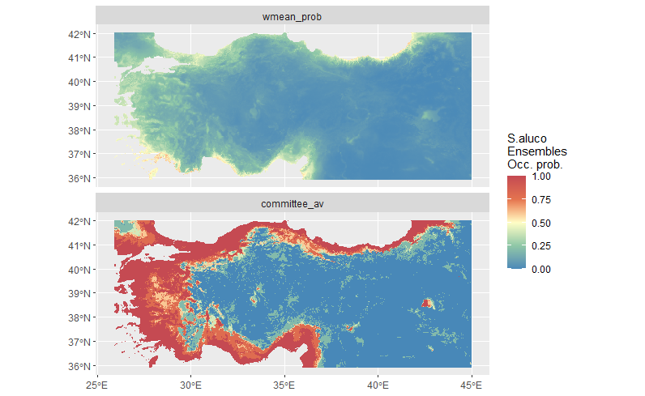

wc2.1 bioc sdm

ssp370 e göre 2081-2100 arası dağılım. miroc6 modelden.

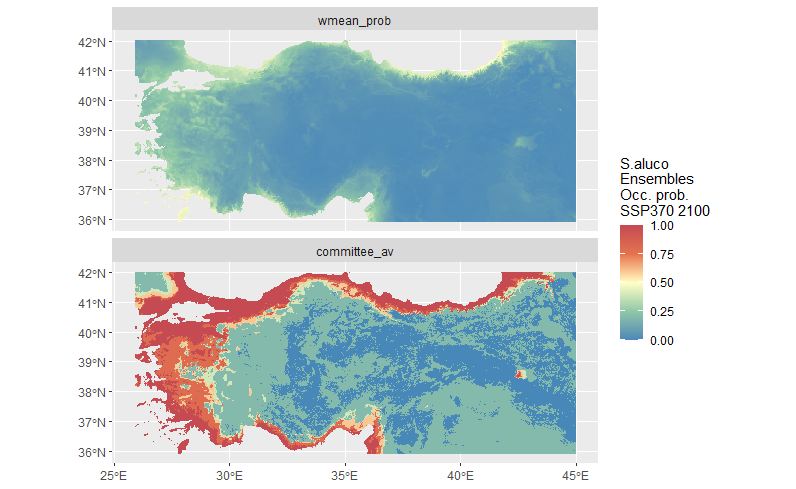

sdm gelecek

Ensemble mean, median ve ağırlıklı mean tahminlerinin

maxSens+Spec threshold’a göre var/yok tahminlerine çevrilmesi.

Günümüz ve gelecek

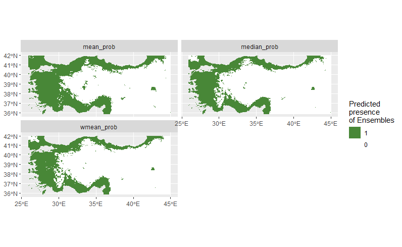

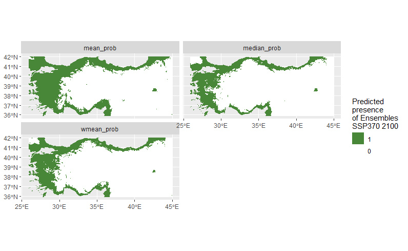

**Quantification of uncertainty**

Ensemble tahminlerinin standard sapmalarının dağılımları: günümüz ve gelecek

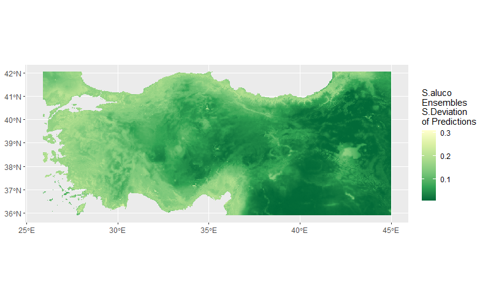

current-sd

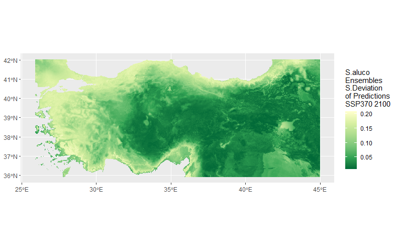

gelecek-sd

Novel environments 2081-2100. Training verisinde karşılaşılmayan durumlar. Uncertainty düşürmek için bu alanlar çıkarılıp tahmin yapılabilir. Küçük alan ve güney alt sınır olduğu için gerek görülmedi.

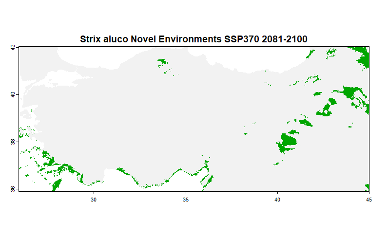

novel-env

**truly independent test data**

Modelin İspanya ve çevre bölgesine tahminleri: önce ağırlıklı mean olasılık tahminleri sonra ensemble committee var/yok tahminleri.

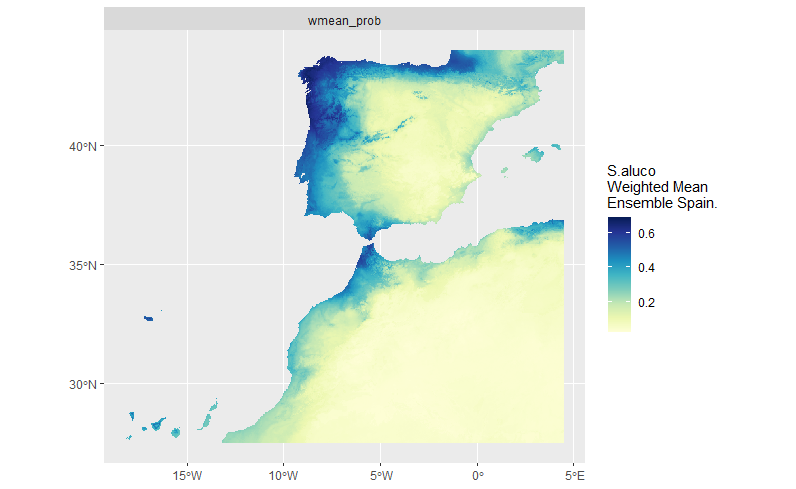

spain-ens-wmean

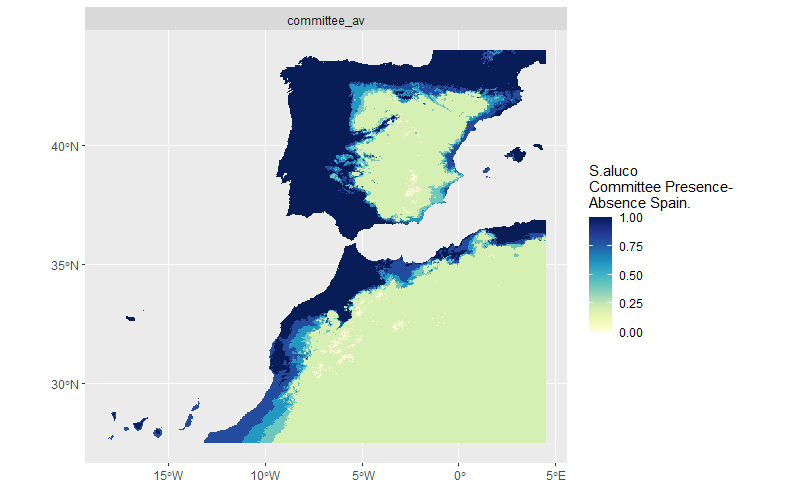

spain-ens-pres-abs

İspanya’da Strix aluco’nun **gözlemlenmediği** noktalar

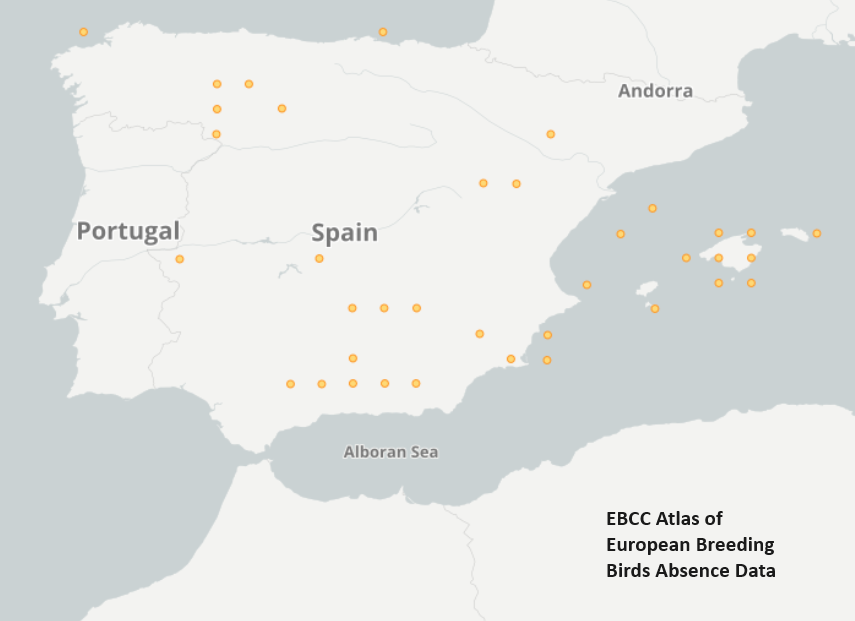

spain-absences

ispanya eBird Strix aluco gözlemlenen noktalar

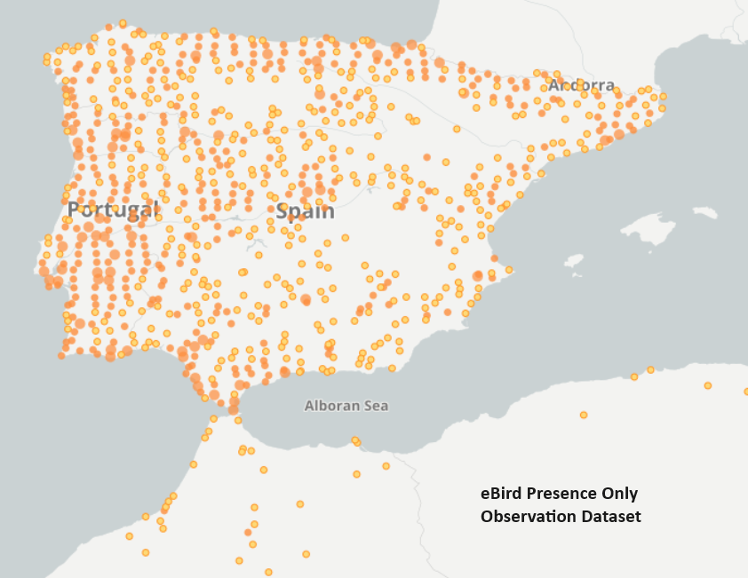

spain-presences